# NotTeamOnelab10

David Orozco, Ethan Schacht, Anderson Mun, Arie del Valle, Ryan Tate

March 20, 2019

#### Team Section

Questions:

- Is there a relationship between total time elapsed since a question was posted and the score of its answer?
- What is the relationship between the timeliness of an answer and its score? That is, does the first response to a question recieve a higher answer score than the following responses?

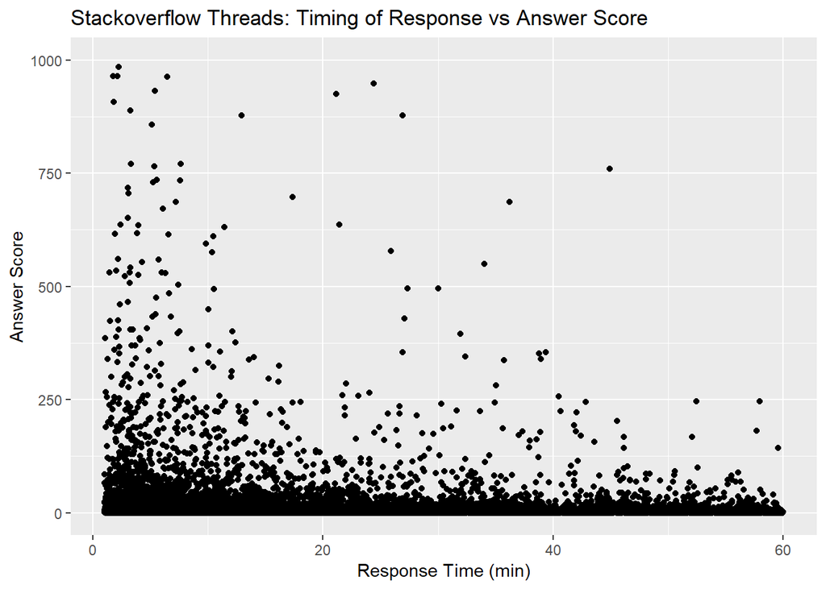

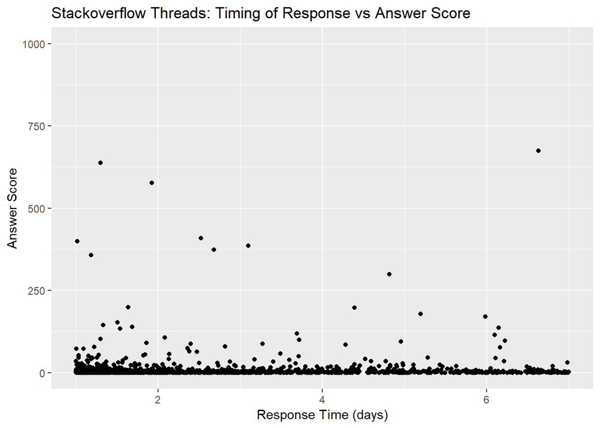

Findings/Explanation:

- We compared the time difference of questions and answers to the answer score. The graph shows that there was not a significant correlation between the two. However, there appears to be a more slight negative correlation if we look at the time range of 0-60 minutes versus larger time ranges. Therefore, we conclude that the time elapsed since a question was asked has little to no affect on the answer score. This could be because people might go through stackoverflow and choose which question they want to answer depending on the quality, not necessarily which one was posted first.

```
## # A tibble: 6 x 5
##   `Answered in...` amount percentage average_score `Score x Amount`
##   <chr>             <dbl>      <dbl>         <dbl>            <dbl>
## 1 seconds              45    0.00140        106               4770
## 2 minutes           18801    0.586           17.1           321497.
## 3 hours              9103    0.284            8.62           78468.
## 4 days               1511    0.0471          10.2            15412.
## 5 weeks              2546    0.0793          11.6            29534.
## 6 years                84    0.00262         50.5             4242
```

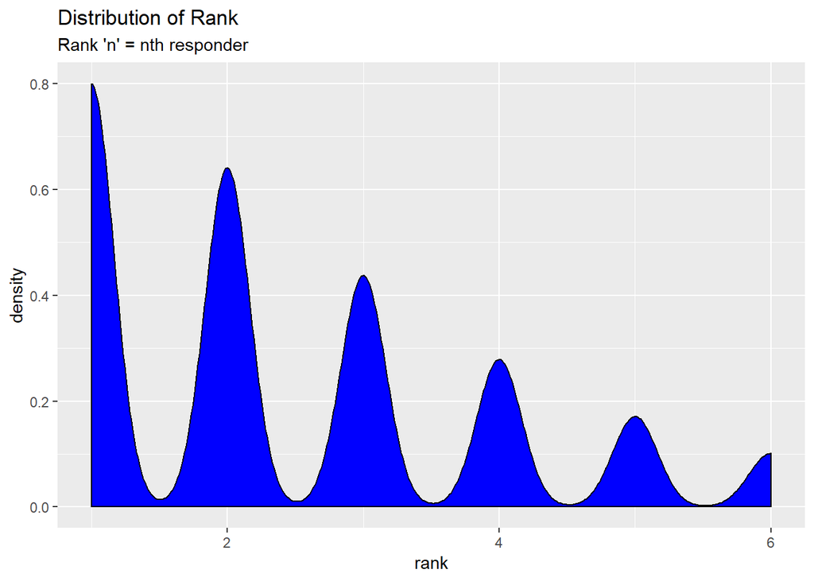

```
## # A tibble: 6 x 3
## # Groups:   rank [6]
##    rank     n percent
##   <dbl> <int>   <dbl>
## 1     1  9935  0.329
## 2     2  7964  0.264
## 3     3  5436  0.180
## 4     4  3466  0.115
## 5     5  2126  0.0704
## 6     6  1258  0.0417
```

- The graph and tibble above shows the distribution of ranks. The graph shows a steady decrease in the denstiy of rank and the rank increases. 33% of all answers are rank 1 but only 18% are rank 3. This makes sense that there are more nth responses than (n+1)th responses. This is becuase the previous answers most likely sufficiently answered the question and there is no need to upload a new one.
- The graph and tibbles here were created in a similar manner has previously discussed. However we used `semi_join` to combine the data with all the ranks with a data set that contained only the top answer score for each question. This resulted in a tibble that contained only the top answer score per question and had a rank. We did this because we wanted to see which rank tends to have the highest score.

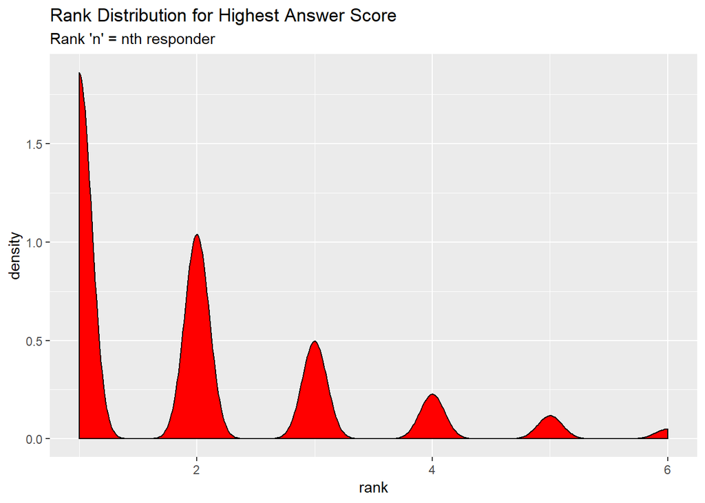

```
## # A tibble: 6 x 3
## # Groups:   rank [6]
##    rank     n percent
##   <dbl> <int>   <dbl>
## 1     1  5243  0.491
## 2     2  2926  0.274
## 3     3  1399  0.131
## 4     4   640  0.0599
## 5     5   333  0.0312
## 6     6   141  0.0132
```

- The graph and tibble above shows the same trend has the Rank Distribution graph. This means that rank 1 answers tend to have the highest answer scores. Of all the top answers, 50% are rank 1. Only 27% are rank 2. This makes sense. There are many questions that only contain one rank, making Rank 1 the highest scoring by default. Also, there is a high chance that the first few questions do a good job of answering the question and recieves a higher score.
- An overlay between the who distributions are shown below. This shows that while they follow the same trend, the red is significatly higer for rank 1-3. This states that for rank 1-3, timeliness of answer does effect what rank recieve the highest score.

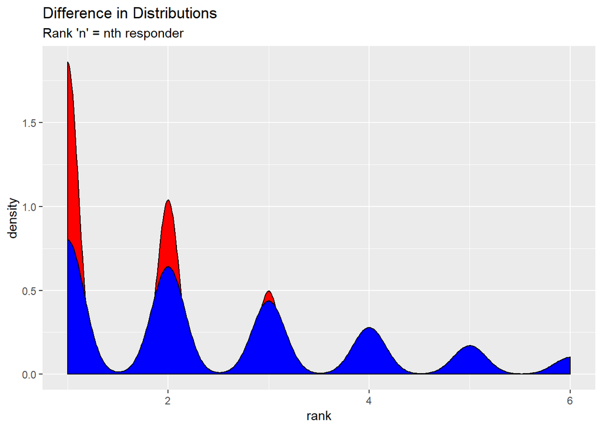

```
## # A tibble: 6 x 2
## # Groups:   rank [6]
##    rank proportion
##   <dbl>      <dbl>
## 1     1      0.528
## 2     2      0.367
## 3     3      0.257
## 4     4      0.185
## 5     5      0.157
## 6     6      0.112
```

- The tibble above shows proportion = (rank n that had the highest answer score)/(all rank n). 52% of all rank 1 are the best answer. 36% of all rank 2 are the best answer. This shows that rank 1 have the highest proportion of top answers.

#### Arie’s Section

- Question: How does the average score of answers compare to the average score of questions that have to do with python?
- Explanation: I wanted to see if questions and answers that specified that they were talking about python had an effect on the overall score of the question and answer.

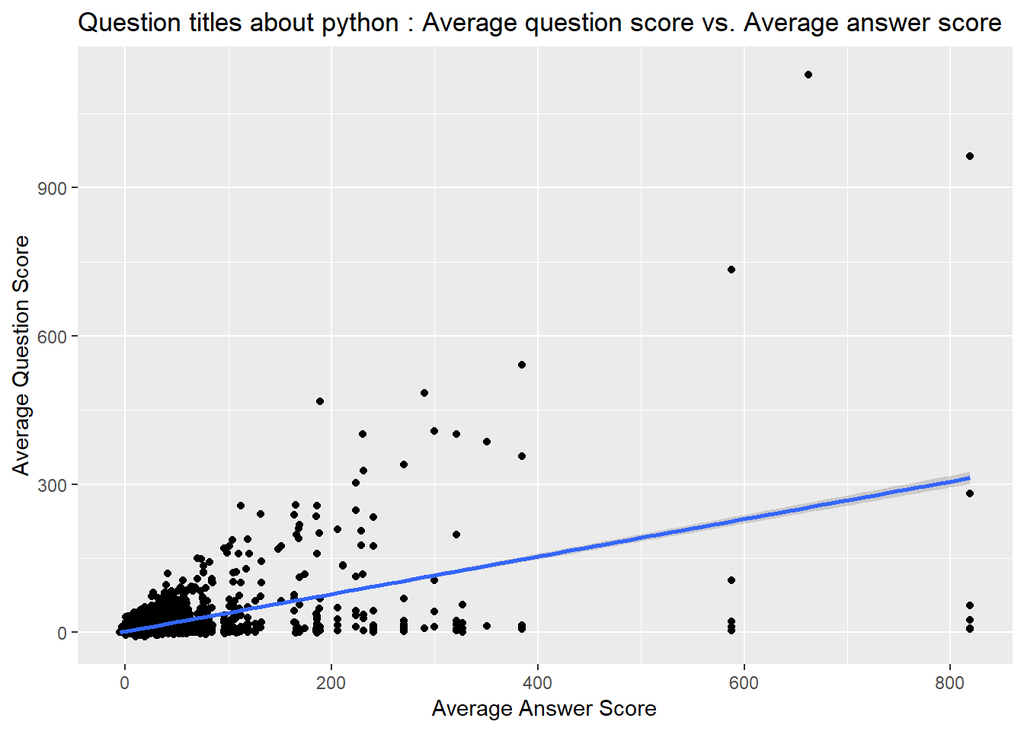

```
## [1] 0.5467967
```

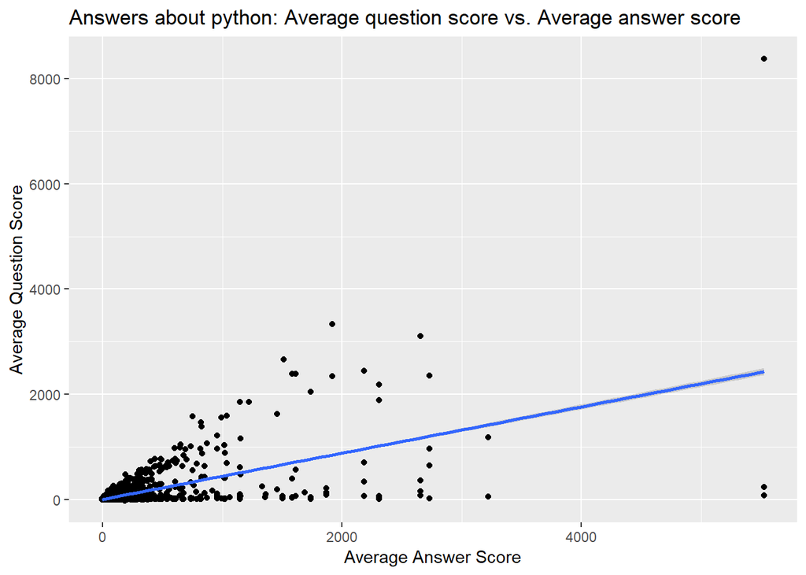

```
## [1] 0.5996668
```

#### David’s Section

- Question: How does the length of a question impact the average answer score for all questions with the same length.
- Explanation: This is important to investigate becuase there might be a correlation between specificity of a question and how well users can answer a question.

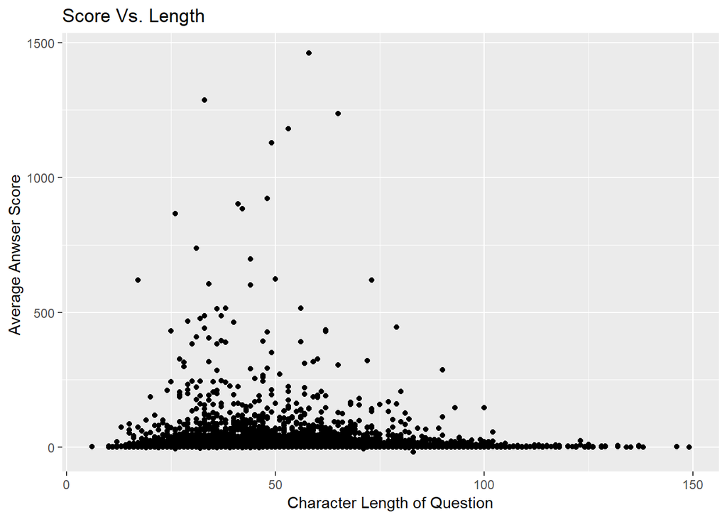

- Process: I created a tibble that showed the average answer score for each unique question. I did this by using verbs such as `group_by` and `mutate` to create new variables. Within `mutate` I used `str_lenght` to count the amount of characters within a question title. Finally, I created a scatter plot using `geom_point` of this data to see if there was a coorelation between question length and answer score.
- Findings: My hypothesis was that there would be a optimum question length for highest answer scores. Linearly, there does not seem to be a coorelation bewteen length and score. I think this is becuase there are substantially more data points that are not outliers to the data. However, a majority of outliers (those questions wih really high answer scores) lie between 25-75 characters. This leads me to believe there is a optimum region where you can find the questions with the highest answer scores.
- Explanantion: This makes sense. I believe this trend as to do with miscommunication. If a question is too short, it is often vague and very broad. When answering a broad question, there are many facets you can address. The answer may not be specifically what the reader was looking for, decreasing the average answer score. If a question is too long, it can be either too specific or too confusing. In this case, the person answering might misinterpret the question leading to an answer that does not help the user.

#### Ethan’s Section

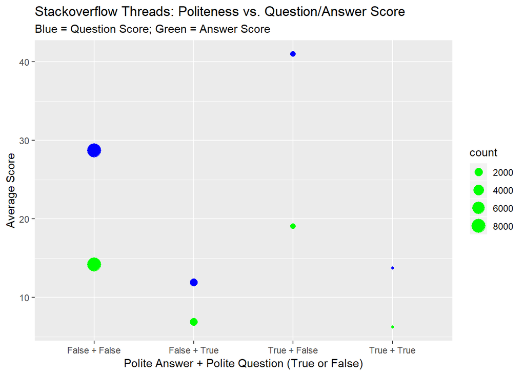

#### Ryan’s Section

##### string length of answer body vs answer score

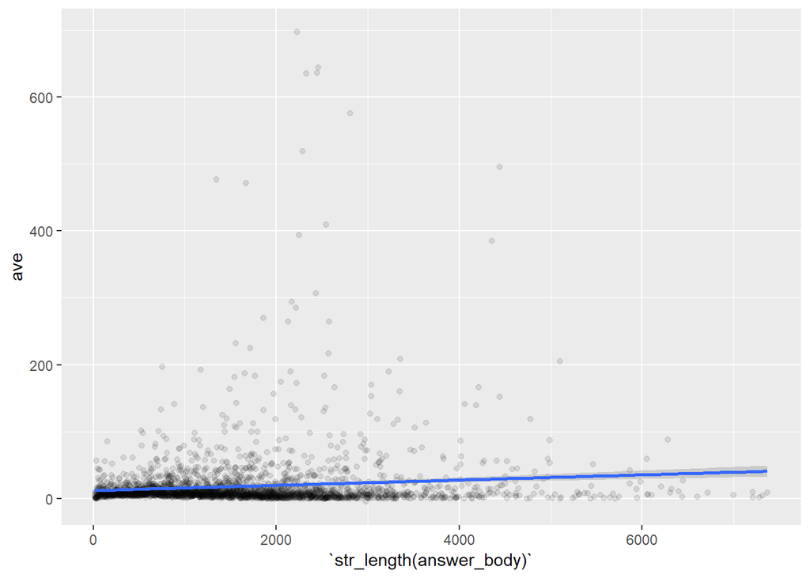

##### falsly postive word count in question body vs average score for question body

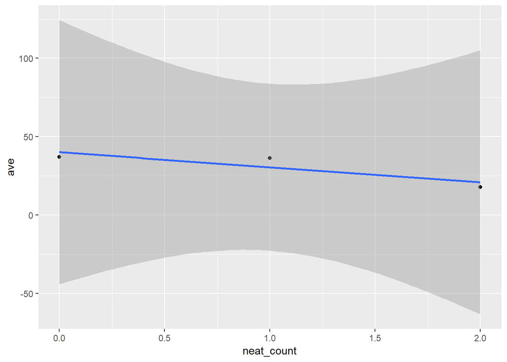

- I created a feature called neat_count because I wanted to see the change in an questions score when they were positive, but maybe also slightly worried, which is displayed through the use of words like “neat”, “neato”,“nice”, and “noice”.
- The relationship between question score and the count of worriedly positive words is slightly negative. This could be due to the fact that people who are worried about their post and try to remain positive are seen as being less honest than if they were just worried about getting an answer. The correlation isn’t very strong though, and this could most likely be due to the fact that just becase someone used the word nice, it does not necessarily imply anything, whether about positivity or the level of worriedness.
- Also, I created a feature called str_length(answer_body) because I wanted to see the change in an answer’s score when the answer became more extensive.
- The relationship between the length of the answer body and the score for the body is slightly positive, probably due to the fact that the more an answer is explained, the more likely the answer is right and thus will be upvoted. However, it is probably not more positive because some of the best answers are realtively simply and don’t need a lot of words explaining them.

#### Anderson’s Section

```
## # A tibble: 5 x 3
##   Questionword   Number_of_questions Average_times_asked
##   <chr>                        <dbl>               <dbl>
## 1 How                            783             0.0244
## 2 What                           319             0.00994
## 3 When                           662             0.0206
## 4 Where                           92             0.00287
## 5 Everythingelse               30240             0.942
```

- I started out with creating several features listed as words that are frequently used in questions. The features included words like how, what, when and where. I used the actions filter and string detect to visualize the questions with the specified words. I also used a count function to retrieve the number of questions with said words in it. To show the results of my data I have created a tribble with the average times questions are asked with certain words in it.
- pf represents the tribble that gives you the data on the questions asked and their results by the numbers. The data in pf is very useful when trying to find out how many questions are asking the what, when, where and how. Through this data you can see that the questions asking how are the most frequent out of the specified words with 783 questions asking how. This number may seem large but when compared to everything else that didn’t include these words there’s only a 2.44% chance your question will ask how.

#### Who did what?

- David - Ind section, started GitKraken Repo, team aspect tibbles and graphs, finding/explanations for team section addressing the second question.
- Arie - ind section and helped write findings for second question.
- Anderson- ind section
- Ethan- ind section and findings, merged and tidied/sorted the two datasets, findings/explanation on team section addressing first question.
- Ryan- indiviudal section, researched data/time information for team section